# Assignment 1: Oakland’s TOD

# 2 Five Time & Space Maps

*Comparing TOD & non-TOD Tracts between 2009 & 2019*

These five maps paint a primer of the housing and demographic change between 2009 and 2019 in the East Bay.

## 2.1 People per Unit

*Total Population per Occupied Housing Units*

Figure 2.1 is the first variable that highlights the overall building and housing conditions of the East Bay. Both the 2009 and 2019 maps highlight the general characteristics of the building density and housing stock: there is more multiple family housing (4+ people per unit) in the areas closer to BART stations and more single family housing farther away from the stations. Of note is the extremely high residents per unit (20+ people) in Berkeley to the university’s student housing. Another important note is the extremely low density, un-changing hills of East Berkeley and Oakland – where the high elevation, large stock of single-family housing, and aging residents makes it difficult to add density.

Between 2009 and 2019, we don’t see too much of a change in location – just a general increase in residents per housing unit. At the same time, West Berkeley, Emeryville, and Far-South Oakland all see an increase from 1.5 people per unit to almost 4 people per unit; this is likely the result of many industrial buildings being converted to apartments.

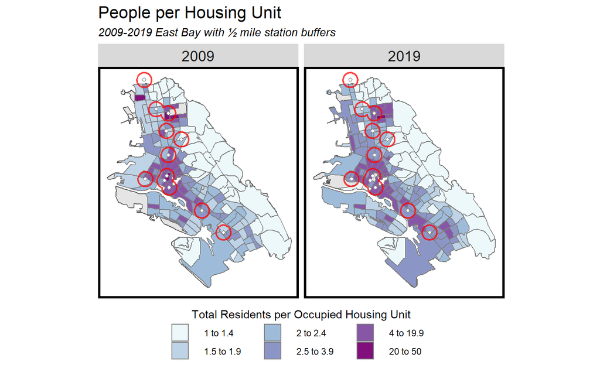

Figure 2.1: People per Unit

```r
options(scipen=999)

get_labels = function(
  cut_breaks, round_digit = 0, bucket_diff=1, first_start_range=0, last_end_range=TRUE, input_end_range='', bucket_suffix='', bucket_prefix=''
){
  labels =
    cut_breaks %>% gsub(",", " to ", .) %>%
    str_sub(., 2, -2) %>% unique(.)

  list_str = function(l, remove=0){
      format(round(as.numeric(l), digit=round_digit)-remove, big.mark=",")}

  for (i in seq(from=1,to=length(labels))){
    bucket_range = labels[i] %>% str_split(., " to ")

    start_range = paste(bucket_prefix, list_str(bucket_range[[1]][1]))
    end_range = paste(list_str(bucket_range[[1]][2], remove=bucket_diff), bucket_suffix)

    if (i == 1 & first_start_range != ''){
      start_range = paste(bucket_prefix, list_str(first_start_range))}
    if (i == length(labels) & input_end_range!=''){
      end_range=paste(list_str(input_end_range), bucket_suffix)
      last_end_range=TRUE
      }
    if (i == length(labels) & last_end_range==FALSE){end_range='+'}

    bucket = paste(
        start_range,
        'to',
        end_range) %>% str_trim()
    labels[i] = bucket}

  return(labels)
  }

plot_vari = function(
  focus_sf  = tracts.all,
  variable  = "dens_pop",
  qbreaks   = qBr(tracts.all, variable),
  bucket_diff = 1,
  title     = "Population Density",
  subtitle  = "2009-2019 East Bay with ½ mile station buffers",
  legend_nm = variable,
  caption   = "",
  brewer_colors = 'Spectral',
  round_digit = 0,
  last_end_range = TRUE,
  input_end_range = '',
  bucket_suffix = '',
  bucket_prefix = '',
  buff_col = 'red',
  col_rev = FALSE,
  first_start_range = 0,
  leg_xspace = .025
){

cutting_field = function(var_field, var_breaks){return(var_field %>% cut(., breaks = var_breaks, dig.lab=10, include.lowest = TRUE))}

focus_sf$cut_field = cutting_field(focus_sf[[variable]], qbreaks)

cut_breaks = sapply(focus_sf$cut_field, function(brk) brk %>% levels())

labels = get_labels(
  cut_breaks,
  round_digit = round_digit, bucket_diff=bucket_diff,
  last_end_range=last_end_range, first_start_range=first_start_range,
  input_end_range=input_end_range, bucket_suffix=bucket_suffix, bucket_prefix=bucket_prefix)

breaks_amount = length(qbreaks)-1
col_vals = brewer.pal(breaks_amount, name=brewer_colors)

if (col_rev==TRUE){col_vals=rev(col_vals)}

return(
ggplot()+
  # geom_sf(data = EB.all, fill=alpha('grey50', .5), color=alpha('grey50', .5)) +
  # geom_sf(data = EB.back_water, fill=alpha('cornflowerblue', .5), color='transparent') +
  geom_sf(data  = EB.cities, fill='grey90')+
  geom_sf(data  = focus_sf, aes(fill    = cut_field), color='grey50') +

  scale_fill_manual(
    values=col_vals,
    labels = labels, name=legend_nm) +
  geom_sf(data=BART.buffers.TOD, fill='transparent', color=alpha(buff_col, alpha=.75), lwd=.75) +
  geom_sf(
    data=BART.stops, fill='white',
    color='grey30', shape=21) +
  # geom_text(
  #   data=EB.labels, check_overlap=TRUE,
  #   size = 3.5, fontface='bold', color='black',
  #   aes(x=lon,y=lat, label=label)) +
  labs(title = title, subtitle = subtitle,
       caption=caption) +
  guides(fill = guide_legend(title.position="top",
                             #reverse=T,
                             title.hjust = 0.5, title.vjust = 0)) +
  theme(legend.position = "bottom",
        legend.spacing.x = unit(leg_xspace, 'in'),
        legend.text = element_text(
          margin = margin(r = .1, unit = 'in')),
        legend.margin=margin(0,0,0,0),
        legend.box.margin=margin(-5,-5,-5,-5)) +
  facet_wrap(~year)+
  mapTheme() + plot_limits()
)}

variable  = "pop_units"

filt_sf = tracts.all[!is.na(tracts.all[[variable]]) &
                      !is.infinite(tracts.all[[variable]])
                       ,]
mx = max(filt_sf[[variable]])

breaks = c(0,1.5,2,2.5,4,20, mx)
#breaks = seq(0, mx, length.out = 4)

plot_vari(
  focus_sf  = filt_sf,
  variable  = variable,
  qbreaks   = breaks,
  title     = "People per Housing Unit",
  brewer_colors = 'BuPu',
  legend_nm = "Total Residents per Occupied Housing Unit",
  bucket_suffix = '',
  input_end_range = '50',
  last_end_range = FALSE,
  round_digit=2,
  bucket_diff=.1,
  first_start_range=1,
  leg_xspace = .2
)
```

```r
#hist(filt_sf[['pop_units']], breaks=500, xlim=c(1,4))
#filt_sf$pop_units<50
```

## 2.2 Rent

*Household Median Rent & Utilities Cost (Adjusted to 2019 inflation)*

The East Bay’s median gross rent reveals a dramatic jump in rent in a 10 year period — even adjusting for the 2019 inflation. A dramatic change is the areas of lower income rent – Downtown Oakland, Fruitvale, Emeryville, and West Berkeley – all seeing a $500 to $1,000 increase in rent. West Berkeley & Emeryville’s dramatic increase in rent and people per unit suggest a drastic change. Most of the immediate TOD tracts have increases, but not unique to the overal increase; so is there a demand for non-TOD housing in the West?.

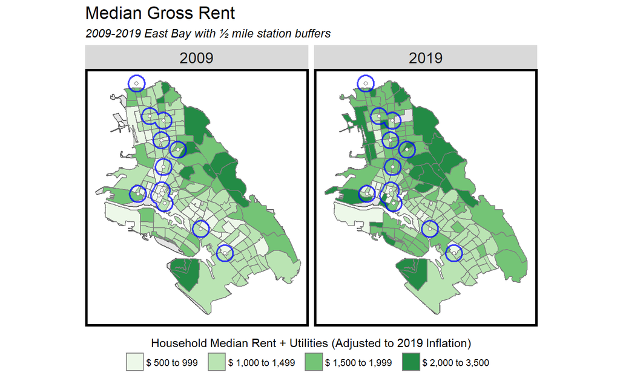

Figure 2.2: Median Rent

```r
variable  = "med_rent_inf"

filt_sf = tracts.all[!is.na(tracts.all[[variable]]) &
                      !is.infinite(tracts.all[[variable]])
                       ,]


mx = max(filt_sf[[variable]])
#breaks = seq(0, mx, length.out = 6)
#breaks = c(0, 10000,20000,30000, mx)
breaks = c(0, 1000, 1500, 2000, mx)

plot_vari(
  focus_sf  = filt_sf,
  variable  = variable,
  qbreaks   = breaks,
  title     = "Median Gross Rent",
  caption   = "",
  brewer_colors = 'Greens',
  legend_nm = "Household Median Rent + Utilities (Adjusted to 2019 Inflation)",
  input_end_range="3500",
  bucket_prefix = '$',
  first_start_range=500,
  buff_col='blue'
)
```

```r
variable = 'med_rent_util_inf'

brewer_colors = 'Greens'
```

## 2.3 Income spent on Rent

*Percent of Median Household Income spent on Rent*

This map of the percent of income spent on rent suggests a large change in personal finances and/or population in many areas of the city. The noticeable change is the actual *decrease* in the percent of income spent on rent – especially West Berkeley, Emeryville, West Oakland, and South Oakland.

Even though it initially appears optimistic that more residents are affording rent, it starts to turn pessimistic when recalling the sharp rise in rent in Figure 2.2. For West Berkeley, Emeryville, and West Oakland, the large increase in rent combined with less income going towards rent suggests the introduction of new units and wealthier residents. One tract in particular on the farthest tip of West Oakland goes from 43% of income going towards rent to only 19% – with a rise of median rent going from $1,552 to $2,750 in that same period.

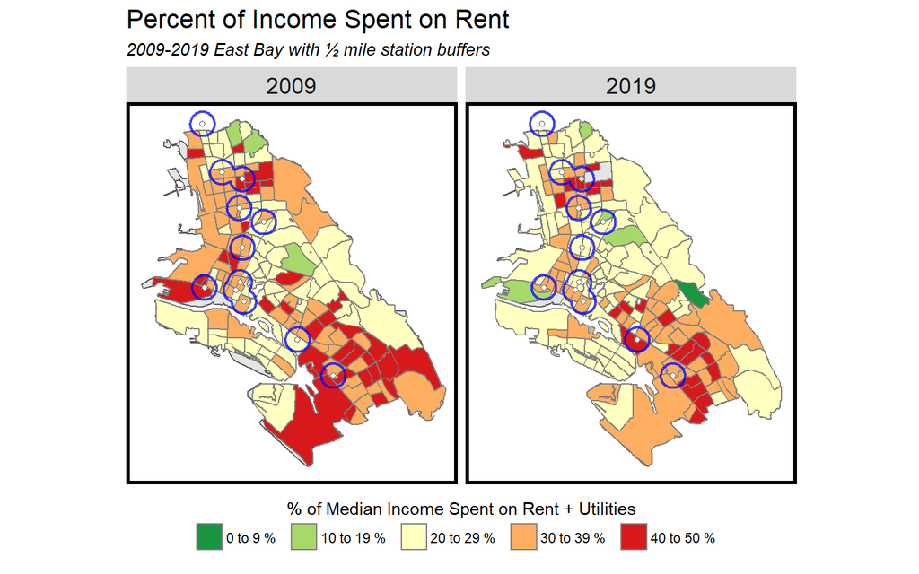

Figure 2.3: Income on Rent

```r
variable  = "pct_med_rent"

filt_sf = tracts.all[!is.na(tracts.all[[variable]]) & !is.infinite(tracts.all[[variable]]),]

mx = max(filt_sf[[variable]])
#breaks = seq(0, mx, length.out = 6)
#breaks = c(0, 10000,20000,30000, mx)
breaks = c(0, 10,20,30,40, mx)

plot_vari(
  focus_sf  = filt_sf,
  variable  = variable,
  qbreaks   = breaks,
  title     = "Percent of Income Spent on Rent",
  brewer_colors = 'RdYlGn',
  legend_nm = "% of Median Income Spent on Rent + Utilities",
  input_end_range='50',
  bucket_suffix='%',
  col_rev=TRUE,
  buff_col='blue'
)
```

## 2.4 Young Adults

*Percent of People between the ages of 22 and 34 compared to total people*

The percent of young adults (Figure 2.4) highlights concentrations of young adults (above 30%). At the same time, the aging Oakland/Berkeley Hills population and the low-income families of South Oakland & Fruitvale retain the same age composition in this period. This map locates the ‘young urban professionals’ who have money, fewer responsibilities, and an ability to move to their location of choice. Northern TOD tracts and West Berkeley seem to receive the largest growth in young adults. The underlying complication of this map is remembering the East Bay’s .003% increase in units for the 10% increase of population during this period.

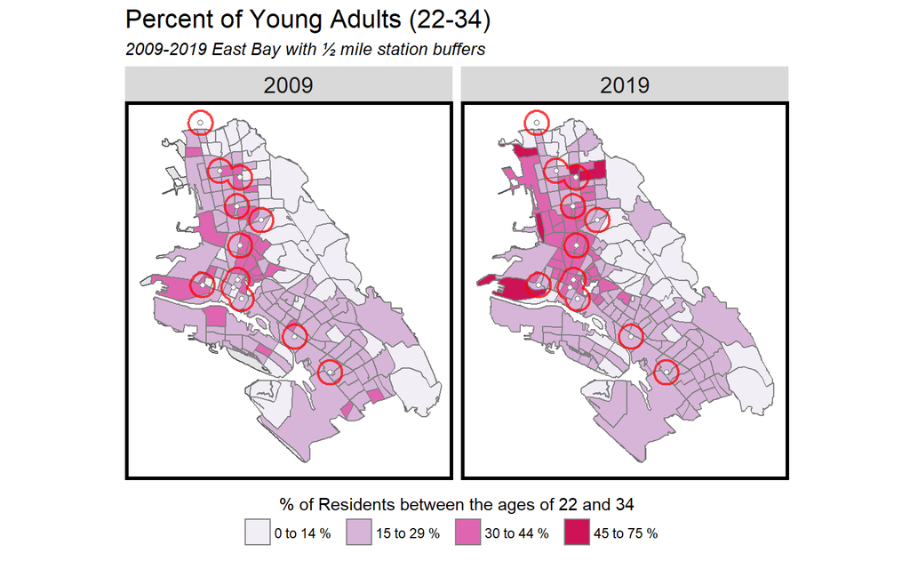

Figure 2.4: Young Adults

```r
variable  = "pct_22_34yo"

filt_sf = tracts.all %>%
  transform(., pct_moved=as.numeric(pct_moved)) %>%
  filter(!is.na(tracts.all[[variable]]) &
                      !is.infinite(tracts.all[[variable]]))

filt_sf[[variable]] = filt_sf[[variable]] * 100
mx = max(filt_sf[[variable]])
#breaks = seq(0, mx, length.out = 5)
breaks = c(0, 15, 30, 45, mx)

filt_sf$cut_field =
  filt_sf[[variable]] %>%
  cut(.,
      breaks = breaks, dig.lab=10, include.lowest = FALSE)

plot_vari(
  focus_sf  = filt_sf,
  variable  = variable,
  qbreaks   = breaks,
  bucket_diff=1,
  round_digit=0,
  title     = "Percent of Young Adults (22-34)",
  caption   = "",
  brewer_colors = 'PuRd',
  legend_nm = "% of Residents between the ages of 22 and 34",
  input_end_range='75',
  bucket_suffix='%',
  col_rev=FALSE
)
```

## 2.5 Employees of Tech & Software companies

*Percent of Employed People in the Information Industry (e.g. Technology, Software, Media) compared to Total Employed People*

This map of the employees of the technology, software and media (Figure 2.5) strikes at the heart of the Bay Area’s booming economy, pricing-out, and ‘gentrification’. There is an increase of tech employees in the previously mentioned young and wealthy areas: Northern TOD tracts, West Berkeley, West Oakland, and Emeryville. At the same time, tech employees start to encroach on the neighborhoods of the typically low-income households: Fruitvale, Downtown Oakland, and West Oakland.

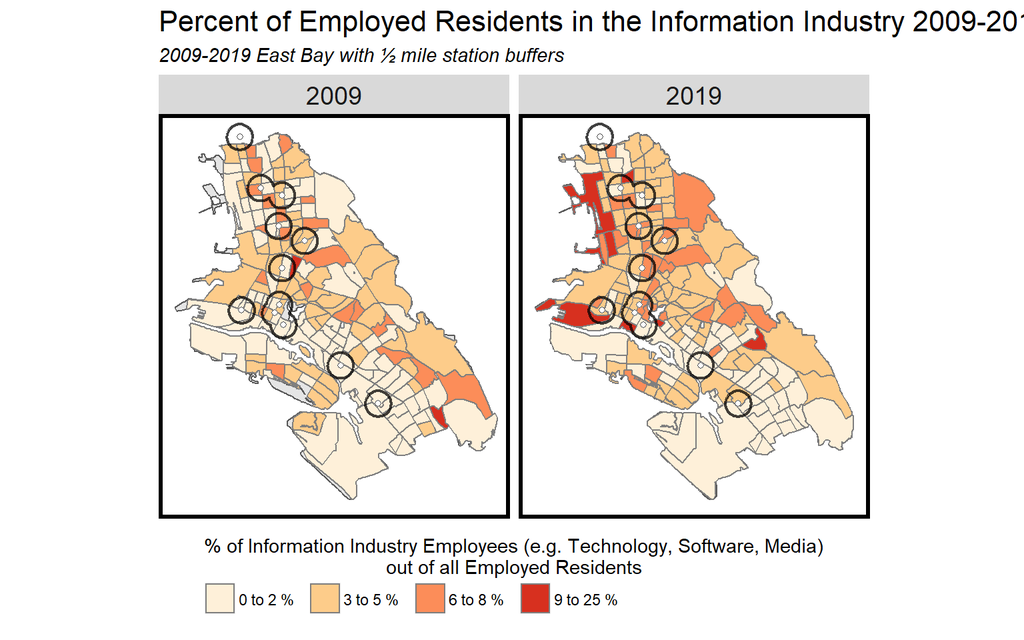

Figure 2.5: Technology Employees

```r
variable  = "pct_emp_info"

filt_sf = tracts.all %>%
  mutate(pct_22_34yo = pct_22_34yo * 100) %>%
  filter(!is.na(tracts.all[[variable]]) &
         !is.infinite(tracts.all[[variable]]))

mx = max(filt_sf[[variable]])
# Break reasons: min, right below mean/median (3.7%, 3.5%), above 3rd quantile, odd spike around 9-10%, max
breaks = c(0, 3, 6, 9, mx)

plot_vari(
  focus_sf  = filt_sf,
  variable  = variable,
  qbreaks   = breaks,
  bucket_diff=1,
  round_digit=0,
  title     = "Percent of Employed Residents in the Information Industry 2009-2019",
  brewer_colors = 'OrRd',
  legend_nm = "% of Information Industry Employees (e.g. Technology, Software, Media)\nout of all Employed Residents",
  input_end_range='25',
  bucket_suffix='%',
  buff_col='Black'
)
```

# 3 Bar Plot

*One grouped bar plot making these same comparisons*

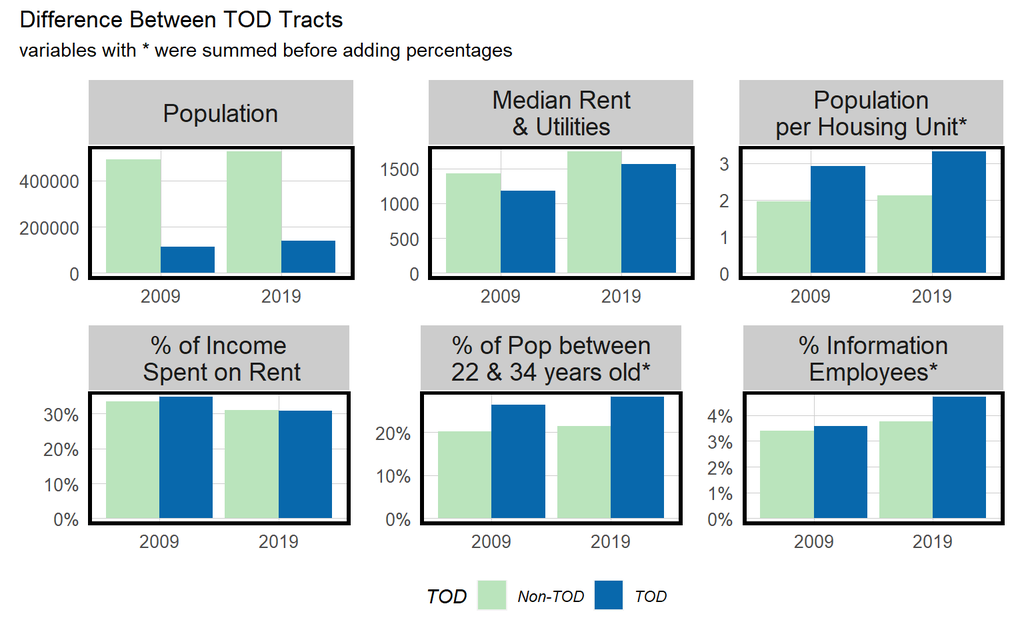

Figure 3.1: Bar Plot

```r
tracts.summary =
  tracts.all %>% st_drop_geometry() %>%
    mutate(
      year = as.character(year),
      pct_moved = pct_moved*100 ) %>%
    group_by(year, TOD) %>%
    summarize(
      # Variable B  Population
      Population    = sum(tot_pop, na.rm=T),
      # Variable A  Rent (Inflation)
      y_Median_Rent   = mean(med_rent_util_inf, na.rm = T),
      # Variable 1  Popultion per Unit
      yy_Pop_per_Unit  = sum(tot_pop, na.rm=T)/sum(tot_units, na.rm=T),
        #mean(ifelse(pop_units>50, NA, pop_units), na.rm = T),
      # Variable 2  % Income Spent on Rent
      z_Income_Rent_per = mean(pct_med_rent, na.rm = T),
      # Variable 3  % Moved in Last Year
      zz_Young_Adult_per = (sum(tot_22_34yo, na.rm=T)/sum(tot_pop, na.rm=T))*100,
      # Variable 4
      zzz_Info_per      = (sum(tot_emp_info, na.rm=T)/sum(tot_emp, na.rm=T))*100)
## `summarise()` has grouped output by 'year'. You can override using the `.groups` argument.

plot_names = list(
  'Population'  = "Population",
  'y_Median_Rent' = "Median Rent\n& Utilities",
  'yy_Pop_per_Unit'= "Population\nper Housing Unit*",
  'z_Income_Rent_per'="% of Income\n Spent on Rent",
  'zz_Young_Adult_per'   = "% of Pop between\n22 & 34 years old*",
  'zzz_Info_per'    = "% Information\nEmployees*"
)
plot_labeller <- function(variable, value){return(plot_names[value])}
col_labeller <- function(Variable, value){return(as.character(plot_names[value]))}

tot_levels = c('Population', 'z_Median_Rent', 'zz_Pop_per_Unit')
per_levels = c('Income_Rent_per', 'Moved_per', 'Info_per')
all_levels = c(tot_levels, per_levels)
total_bars =
  tracts.summary %>%
  select(-z_Income_Rent_per, -zz_Young_Adult_per, -zzz_Info_per) %>%
    gather(Variable, Value, -year, -TOD) %>%
  ggplot() +
    geom_bar(stat = "identity", position = "dodge",
             aes(year, Value, fill = TOD)) +
    facet_wrap(Variable ~ .,
               scales = "free", ncol=3,
               labeller=plot_labeller,
               ) +
    scale_fill_manual(values = c("#bae4bc", "#0868ac"), guide='none') +
    labs(x=NULL, y=NULL) +
    theme(panel.spacing = unit(1, "lines")) +
    plotTheme()


percent_bars =
  tracts.summary %>%
  select(-Population, -y_Median_Rent, -yy_Pop_per_Unit) %>%
    gather(Variable, Value, -year, -TOD) %>%
    #mutate(Variable=factor(Variable, levels=per_levels)) %>%
  ggplot() +
    geom_bar(stat = "identity", position = "dodge",
             aes(year, Value, fill = TOD)) +
    facet_wrap(~Variable,
               #~reorder(Variable, all_levels, first),
               #~factor(Variable, levels = per_levels),
               scales = "free", ncol=3,
               labeller=plot_labeller
               ) +
    scale_fill_manual(values = c("#bae4bc", "#0868ac")) +
    labs(x=NULL, y=NULL) +
    theme(panel.spacing = unit(1, "lines")) +
    scale_y_continuous(labels = function(x) paste0(x, "%")) +
    plotTheme() + theme(legend.position="bottom")


total_bars / percent_bars +
  plot_annotation(title = "Difference Between TOD Tracts",
                  subtitle = "variables with * were summed before adding percentages") + plotTheme()
```

# 4 Table

*One table making these same comparisons*

The table adds in the numbers previously discussed in the last section.

```r
plot_names = list(
  'Population'  = "Population",
  'y_Median_Rent'        = "Median Rent & Utilities(Adjusted)",
  'yy_Pop_per_Unit'= "Population per Housing Unit",
  'z_Income_Rent_per'="% of Income Spent on Rent",
  'zz_Young_Adult_per'   = "% of Population between the ages of 22 and 34",
  'zzz_Info_per'    = "% of Population in the Information Industry"
)

col_labeller = function(value){return(as.character(plot_names[value]))}
rounder = function(value, colname){return(paste(
  ifelse(str_sub(colname,1,4)=='z_Median_Rent', '$ ', ''),
  format(round(value, digit = ifelse(value>31,0,2)),drop0trailing=TRUE, big.mark=","),
  ifelse(str_sub(colname,-4,-1)=='_per', ' %', ''), sep=''))}

tracts.table =
  tracts.summary %>%
    unite(year.TOD, year, TOD, sep = ": ", remove = T) %>%
    gather(Variable, Value, -year.TOD) %>%
    mutate(Value = rounder(Value,Variable)) %>%
    spread(year.TOD, Value) %>%
    arrange(., Variable) %>%
    mutate(Variable=col_labeller(Variable)) %>%
    # mutate(Variable = factor(Variable, levels =c("Population","Median Rent & Utilities(Adjusted)","Population per Housing Unit","% of Income Spent on Rent","% of Population that Moved this Year","% of Population in the Information Industry"))) %>%
    kable(., col.names = c("Mean Variables","non-TOD","TOD","non-TOD","TOD"), align="lrrrr") %>%
      kable_styling() %>%
      footnote(general_title = "\n", general = "Table 1.3") %>%
      add_header_above(., header = c(" "=1, "2009" = 2, "2019" = 2))
 #col.names = c("","2009","2009","2019","2019")
tracts.table
```

| Mean Variables | 2009 non-TOD | 2009 TOD | 2019 non-TOD | 2019 TOD |
| --- | --- | --- | --- | --- |
| Population | 491,334 | 113,921 | 527,363 | 140,761 |
| Median Rent & Utilities(Adjusted) | 1,426 | 1,181 | 1,746 | 1,565 |
| Population per Housing Unit | 1.96 | 2.92 | 2.13 | 3.33 |
| % of Income Spent on Rent | 33 % | 35 % | 30.88 % | 30.81 % |
| % of Population between the ages of 22 and 34 | 20.2 % | 26.4 % | 21.52 % | 28.32 % |
| % of Population in the Information Industry | 3.41 % | 3.58 % | 3.76 % | 4.72 % |

Table 1.3

# 5 Graduated Symbol Maps

*Two Graduated Symbol Maps within 0.5 miles transit stations*

The graduate symbols maps highlight the specific TOD trends for Berkeley and Oakland.

## 5.1 Map of Population within ½ Mile of BART Stations

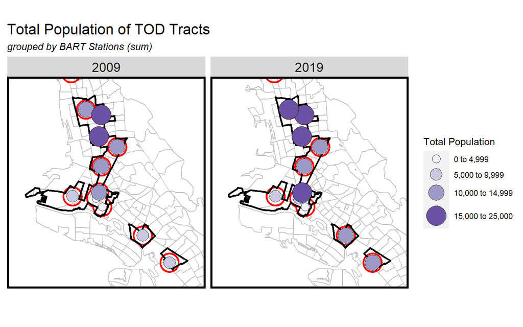

Figure 5.1: Population Graduated Symbol

```r
variable = 'pop'

brewer_colors = 'Purples'

stops.TOD =
  tracts.all[tracts.all$TOD=='TOD',] %>% st_drop_geometry() %>%
    group_by(closest_BART, year) %>%
    summarize(
      rent = mean(med_rent_inf, na.rm=TRUE),
      pop=sum(tot_pop, na.rm=TRUE)) %>% rename(stop_id = closest_BART) %>%
    merge(.,
          BART.stops %>% select(stop_id),
          by='stop_id', left=TRUE)%>% st_as_sf()
## `summarise()` has grouped output by 'closest_BART'. You can override using the `.groups` argument.

plot_title = "Total Population within ½ Mile of BART Stations"
legend_title = "Total Population"
subtitle = "East Bay Census Tracts & BART Stations"
caption = "Map 5.A"

filt_sf = stops.TOD[!is.na(stops.TOD[[variable]]) &
                    !is.infinite(stops.TOD[[variable]])
                       ,]

mx = max(filt_sf[[variable]])

qbreaks = c(0, 5000, 10000, 15000, 25000)
#qbreaks = seq(0, mx, length.out = 5)

cutting_field = function(var_field, var_breaks){return(var_field %>% cut(., breaks = var_breaks, dig.lab=10, include.lowest = TRUE))}

filt_sf$cut_field = cutting_field(filt_sf[[variable]], qbreaks)

cut_breaks = sapply(filt_sf$cut_field, function(brk) brk %>% levels())

labels = get_labels(
  cut_breaks,
  round_digit = 0,
  bucket_diff = 1,
  last_end_range  = TRUE,
  first_start_range   = '',
  input_end_range = '25000',
  bucket_suffix = '')

breaks_amount = length(qbreaks)-1
col_vals = brewer.pal(breaks_amount, name=brewer_colors)

ggplot()+
  #POLYGON
  geom_sf(data = tracts.all, fill = "white",color = "grey75")+
  geom_sf(
    data=BART.buffers.TOD,
    fill='transparent', color='red', lwd=1) +
  geom_sf(
    data=tracts.TOD %>% filter(year==2019) %>% st_union(),
    fill='transparent', color='Black', lwd=1)+
  geom_sf(
    data=BART.stops, fill='white',
    color='grey30', shape=21) +
  # POINT
  geom_sf(data = filt_sf,
          shape = 21, color='grey10',
          aes(size = cut_field, fill = cut_field)) +
  scale_size_manual(
          values = seq(4, 10, length.out = breaks_amount),
          labels = labels,
          name=legend_title)+
  scale_fill_manual(
      values = col_vals,
      labels = labels,
      name='Total Population', guide='none') +
  labs(title = 'Total Population of TOD Tracts',
       subtitle = 'grouped by BART Stations (sum)',
       caption = '') +
  guides(size =
      guide_legend(override.aes = list(fill = col_vals))) +
  theme(axis.title=element_blank(),axis.text=element_blank(),
        axis.ticks=element_blank(), panel.background = element_rect(fill='gray')) +
  facet_wrap(~year)+
  mapTheme() + plot_limits(tracts.TOD %>% filter(year==2019), buffer=mile*.5)
```

## 5.2 Map of Rent within ½ Mile of BART Stations

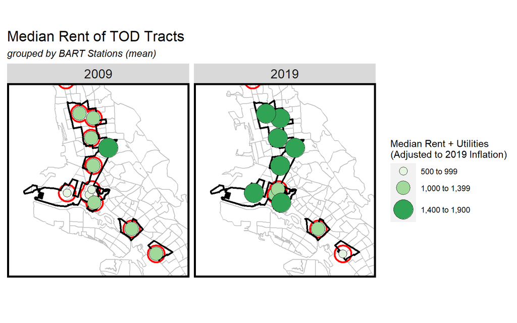

Figure 5.2: Rent Graduated Symbol

```r
variable = 'rent'

brewer_colors = 'Greens'

plot_title = "Median Gross Rent within ½ Mile of BART Stations"
legend_title = "Median Rent + Utilities\n(Adjusted to 2019 Inflation)"
subtitle = "East Bay Census Tracts & BART Stations"
caption = ""

filt_sf = stops.TOD[!is.na(stops.TOD[[variable]]) &
                    !is.infinite(stops.TOD[[variable]])
                       ,]

mx = max(filt_sf[[variable]])

qbreaks = c(500,1000, 1400, 1900)
#qbreaks = seq(min(filt_sf[[variable]]), mx, length.out = 4)

cutting_field = function(var_field, var_breaks){return(var_field %>% cut(., breaks = var_breaks, dig.lab=10, include.lowest = TRUE))}

filt_sf$cut_field = cutting_field(filt_sf[[variable]], qbreaks)

cut_breaks = sapply(filt_sf$cut_field, function(brk) brk %>% levels())

labels = get_labels(
  cut_breaks,
  round_digit = 0,
  bucket_diff = 1,
  last_end_range  = TRUE,
  first_start_range  = '500',
  input_end_range = '1900',
  bucket_suffix = '')

breaks_amount = length(qbreaks)-1
col_vals = brewer.pal(breaks_amount, name=brewer_colors)

ggplot()+
  #POLYGON
  geom_sf(data = tracts.all, fill = "white",color = "grey75")+
  geom_sf(
    data=BART.buffers.TOD,
    fill='transparent', color='red', lwd=1) +
  geom_sf(
    data=tracts.TOD %>% filter(year==2019) %>% st_union(),
    fill='transparent', color='Black', lwd=1)+
  geom_sf(
    data=BART.stops, fill='white',
    color='grey30', shape=21) +
  # POINT
  geom_sf(data = filt_sf %>% st_centroid(),
          shape = 21, color='grey10',
          aes(size = cut_field, fill = cut_field)) +
  scale_size_manual(
          values = seq(4, 10, length.out = breaks_amount),
          labels = labels,
          name=legend_title)+
  scale_fill_manual(
      values = col_vals,
      labels = labels,
      name='Median Rent + Utilities\n averaged by BART Stop', guide='none') +
  labs(title = 'Median Rent of TOD Tracts',
       subtitle = 'grouped by BART Stations (mean)',
       caption = '') +
  guides(size =
      guide_legend(override.aes = list(fill = col_vals))) +
  theme(axis.title=element_blank(),axis.text=element_blank(),
        axis.ticks=element_blank(), panel.background = element_rect(fill='gray')) +
  facet_wrap(~year)+
  mapTheme() + plot_limits(tracts.TOD %>% filter(year==2019), buffer=mile*.5)
```

# 6 Rent, Homelessness, & Distance to BART

In the following plots, the study’s focus will temporarily narrow down to the City of Oakland and the years of 2009, 2014, and 2019. The scope allows the use of the City of Oakland’s 311 citizen request service – specifically looking at requests to remove homeless encampments. Homelessness in the Bay Area has increased tremendously in the past 20 years – with rising rents being a considerable cause.

In Figure 6.1, both the rent and amount of homeless encampment requests are compared to the distance of BART. Specifically, there is a significant rise in rent and requests to remove homeless encampments over the last 10 years. For rent and distance to BART, rent increases with distance to BART – likely due to the larger house sizes in the Oakland Hills, the small amount of tracts that are over 2.5 miles from BART, and the small amount of units for rent father from BART. The increase in rent between 2014 and 2019 is very noticeable, regardless of distance to BART.

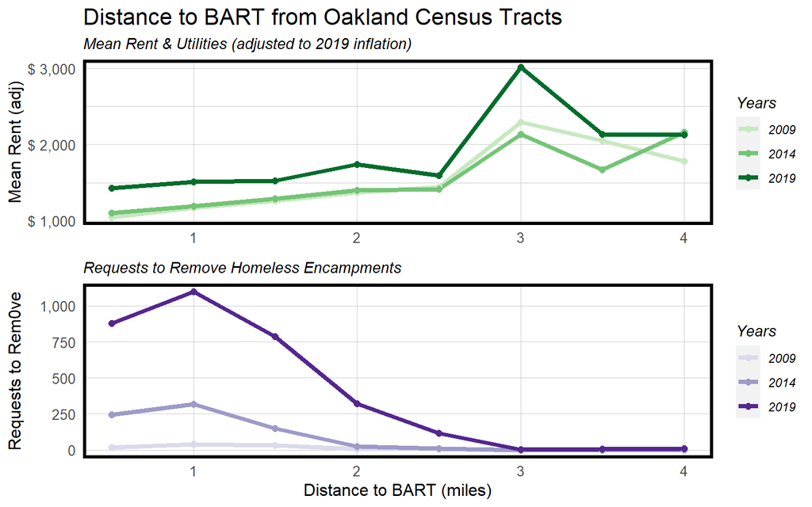

Figure 6.1: Rent, Homeless, & Distance to BART

```r
buff_breaks = seq(0,5,by=.5)

tracts.OAK$BART_dist = cut(
  tracts.OAK$dist_BART/mile, breaks = buff_breaks,
  dig.lab=10, include.lowest = TRUE,
  labels =  seq(.5,5,by=.5))

tracts.OAK.mile =
  tracts.OAK %>% st_drop_geometry() %>%
  group_by(year, BART_dist) %>%
  summarize(
    tracts = n(),
    mean_rent = mean(med_rent_inf, na.rm=TRUE),
    Homeless_Encampment = sum(Homeless_Encampment),
    Illegal_Dumping = sum(Illegal_Dumping)
  ) %>% ungroup(.) %>%
  mutate(
    BART_dist = as.numeric(as.character(BART_dist)),
    year = as.character(year)
    )
## `summarise()` has grouped output by 'year'. You can override using the `.groups` argument.

rent_breaks = c(1000,1500,2000,2500,3000)
rent_labels = c("$ 1,000","","$ 2,000","","$ 3,000")
rent =
  ggplot(data=tracts.OAK.mile,
         aes(x=BART_dist,
             y=mean_rent, color=year)) +
  geom_line(lwd=1.5)+
  geom_point(size=2)+
  labs(
      title = "Distance to BART from Oakland Census Tracts",
      subtitle="Mean Rent & Utilities (adjusted to 2019 inflation)") +
  scale_color_brewer(palette="Greens") +
  scale_y_continuous(
    breaks = rent_breaks,
    labels = rent_labels,
    name = "Mean Rent (adj)") +
  theme(axis.title.x=element_blank()) +
  scale_color_manual(
    name = "Years",
    values=brewer.pal(6, name="Greens")[c(2,4,6)])  + plotTheme()
## Scale for 'colour' is already present. Adding another scale for 'colour',
## which will replace the existing scale.

home_breaks = c(0,250,500,750,1000)
home_labels = c("0","250","500","750","1,000")
homeless =
  ggplot(data=tracts.OAK.mile,
         aes(x=BART_dist,
             y=Homeless_Encampment, color=year)) +
  geom_line(lwd=1.5)+
  geom_point(size=2)+
  scale_y_continuous(
    breaks = home_breaks,
    labels = home_labels,
    name = "Requests to Rem0ve") +
  scale_x_continuous(
    name = "Distance to BART (miles)") +
  labs(
    subtitle="Requests to Remove Homeless Encampments") +
  scale_color_manual(
    name = "Years",
    values=brewer.pal(6, name="Purples")[c(2,4,6)]) + plotTheme()



library(cowplot)
plot_grid(rent, homeless, align='v', ncol=1) +
  labs(title = "Rent, Homelessness, BART Distances")
```

For requests to remove homeless encampments, it is noticeably higher closer to BART. This is likely due to the larger amount of open space, transportation options, and resources closer to Downtown and the bay. Like rent, there is a noticeable jump in homelessness requests from 2014 to 2019.

Taking in all 311 requests (e.g. Illegal Dumping, Littering, Abandoned cars) into account, the homeless encampment requests’ increase went far beyond the all requests – with all requests increasing by 83% from 2014 to 2019, but homeless requests increasing by 330%.

Looking at Figure 6.2, the homeless encampments locate themselves on the bay shores and along the BART routes. This likely is to maximize the open land (compared to the low density of the hills) and the amount of resources close to higher density transit areas.

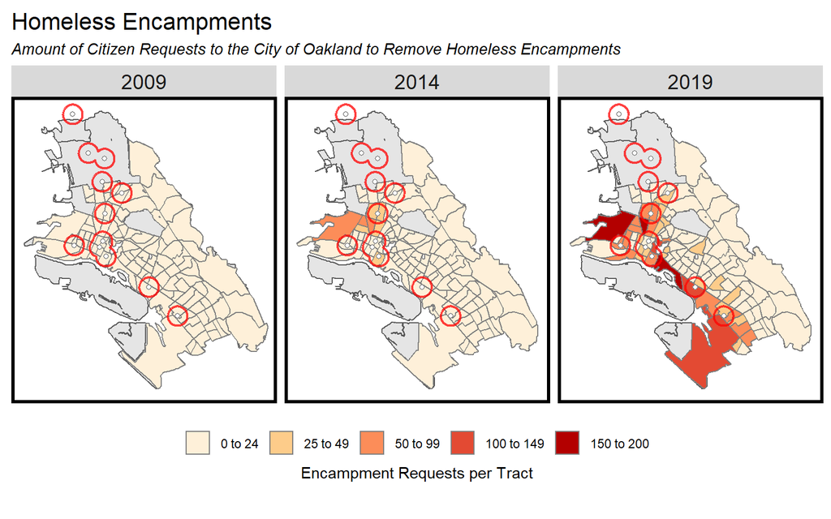

Figure 6.2: Homeless Map

```r
plot_vari_spec = function(
  focus_sf  = tracts.all,
  variable  = "dens_pop",
  qbreaks   = qBr(tracts.all, variable),
  bucket_diff = 1,
  title     = "Population Density 2009-2019",
  subtitle  = "East Bay with ½ mile buffer from BART stations",
  legend_nm = variable,
  caption   = "",
  brewer_colors = 'Spectral',
  round_digit = 0,
  last_end_range = TRUE,
  input_end_range = '',
  bucket_suffix = '',
  buff_col = 'red',
  col_rev = FALSE,
  first_start_range = 0
){

cutting_field = function(var_field, var_breaks){return(var_field %>% cut(., breaks = var_breaks, dig.lab=10, include.lowest = TRUE))}

focus_sf$cut_field = cutting_field(focus_sf[[variable]], qbreaks)

cut_breaks = sapply(focus_sf$cut_field, function(brk) brk %>% levels())

labels = get_labels(
  cut_breaks,
  round_digit = round_digit, bucket_diff=bucket_diff,
  last_end_range=last_end_range, first_start_range=first_start_range,
  input_end_range=input_end_range, bucket_suffix=bucket_suffix)

breaks_amount = length(qbreaks)-1
col_vals = brewer.pal(breaks_amount, name=brewer_colors)

if (col_rev==TRUE){col_vals=rev(col_vals)}

return(
ggplot()+
  # geom_sf(data = EB.all, fill=alpha('grey50', .5), color=alpha('grey50', .5)) +
  # geom_sf(data = EB.back_water, fill=alpha('cornflowerblue', .5), color='transparent') +
  geom_sf(data  = EB.cities, fill='grey90')+
  geom_sf(data  = focus_sf, aes(fill    = cut_field), color='grey50') +

  scale_fill_manual(
    values=col_vals,
    labels = labels, name=legend_nm) +
  geom_sf(data=BART.buffers.TOD, fill='transparent', color=alpha(buff_col, alpha=.75), lwd=.75) +
  geom_sf(
    data=BART.stops, fill='white',
    color='grey30', shape=21) +
  # geom_text(
  #   data=EB.labels, check_overlap=TRUE,
  #   size = 3.5, fontface='bold', color='black',
  #   aes(x=lon,y=lat, label=label)) +
  labs(title = title, subtitle = subtitle,
       caption=caption) +
  guides(fill = guide_legend(title.position="bottom",
                             title.hjust = 0.5, title.vjust = 0)) +
  theme(legend.position = "bottom",
        legend.spacing.x = unit(.1, 'in')) +
  facet_wrap(~year)+
  mapTheme() + plot_limits()
)}

################

variable  = "Homeless_Encampment"

filt_sf = tracts.OAK[!is.na(tracts.OAK[[variable]]) &
                      !is.infinite(tracts.OAK[[variable]])
                       ,]
mx = max(filt_sf[[variable]])

breaks = c(0,25,50,100, 150, mx)
#breaks = seq(0, mx, length.out = 4)

plot_vari_spec(
  focus_sf  = filt_sf,
  variable  = variable,
  qbreaks   = breaks,
  title     = "Homeless Encampments",
  subtitle  = "Amount of Citizen Requests to the City of Oakland to Remove Homeless Encampments",
  caption   = "",
  brewer_colors = 'OrRd',
  legend_nm = "Encampment Requests per Tract",
  bucket_suffix = '  ',
  input_end_range = '200',
  last_end_range = FALSE,
  round_digit=0,
  bucket_diff=1,
  first_start_range=0
)
```

```r
### how much homeless compares to other
```

# 7 Policy Brief